# eDNA Cost-Benefit Analysis: Optimizing COTS Control

### Key Savings Estimates

```r
# Extract Approach D per-reef net savings
edna_net_row <- boot_edna_manta$per_reef %>% filter(metric == "Net dollar savings per reef (after eDNA cost)")
edna_hrs_row <- boot_edna_manta$per_reef %>% filter(metric == "Hours saved per reef")

# Extract Approach D scaled program savings
edna_scaled_net_row <- boot_edna_manta$scaled %>% filter(metric == "Annual net savings (after eDNA costs)")
edna_scaled_hrs_row <- boot_edna_manta$scaled %>% filter(metric == "Annual hours saved")

cat(paste0(
  "\n\n::: {.callout-note}\n",
  "## Expected Savings: eDNA + Manta (Approach D)\n\n",
  "Using the eDNA + Manta approach (Approach D) at an operational scale of **", operational_tactical_reefs, " reefs per year**:\n\n",
  "#### Per-Reef Estimates\n",
  "- **", round(edna_hrs_row$median, 1), " diver hours saved** (80% CI: ",
    round(edna_hrs_row$ci_lower, 1), "–", round(edna_hrs_row$ci_upper, 1), ")\n",
  "- **", dollar(edna_net_row$median), " net savings** (80% CI: ",
    dollar(edna_net_row$ci_lower), "–", dollar(edna_net_row$ci_upper), ") after eDNA costs\n\n",
  "#### Annual Program Projections\n",
  "- **", format(round(edna_scaled_hrs_row$median, 0), big.mark = ","), " total diver hours saved** (80% CI: ",
    format(round(edna_scaled_hrs_row$ci_lower, 0), big.mark = ","), "–", format(round(edna_scaled_hrs_row$ci_upper, 0), big.mark = ","), ")\n",
  "- **", dollar(edna_scaled_net_row$median), " net annual savings** (80% CI: ",
    dollar(edna_scaled_net_row$ci_lower), "–", dollar(edna_scaled_net_row$ci_upper), ") after all eDNA costs\n\n",
  "**Break-even probability:** ", round(boot_edna_manta$breakeven_prob * 100, 1),
  "% of bootstrap replicates show positive net savings at the program level.\n",
  ":::\n\n"
))
```

**Expected Savings: eDNA + Manta (Approach D)**

Using the eDNA + Manta approach (Approach D) at an operational scale of **55 reefs per year**:

#### Per-Reef Estimates

- **9.8 diver hours saved** (80% CI: 6.1–13.9)
- **$6,452.05 net savings** (80% CI: $2,808.13–$10,547.83) after eDNA costs

#### Annual Program Projections

- **538 total diver hours saved** (80% CI: 338–763)
- **$354,863 net annual savings** (80% CI: $154,447–$580,131) after all eDNA costs

**Break-even probability:** 99.3% of bootstrap replicates show positive net savings at the program level.

## Sensitivity Analysis: Unit Cost Assumptions

The financial estimates above depend on assumed cost parameters. This section examines how the **net annual savings for Approach D** (eDNA + Manta) change as we vary each assumption independently, holding others at their base values.

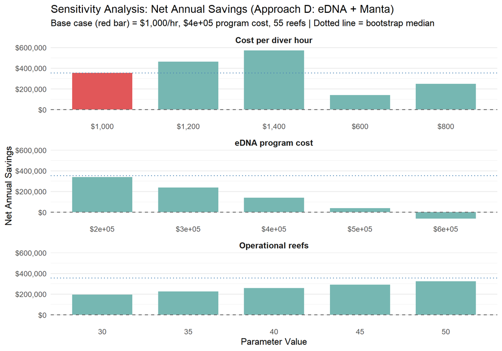

```r
# Compute based on actual eDNA program cost, not per-reef
edna_total_program_cost <- program_cost

sens <- sensitivity_analysis(
  boot_result = boot_edna_manta,
  cost_per_hour_range = seq(600, 1400, 200),
  edna_program_cost_range = seq(200000, 600000, 100000),
  n_reefs_range = seq(30, 50, 5)
)

# Get base case net savings (median from bootstrap)
base_net <- median(boot_edna_manta$boot_dist$scaled_net_savings, na.rm = TRUE)

ggplot(sens, aes(x = value_label, y = net_annual_savings, fill = is_base)) +
  geom_col(show.legend = FALSE, width = 0.7) +
  geom_hline(yintercept = 0, linetype = "dashed", colour = "grey40") +
  geom_hline(yintercept = base_net, linetype = "dotted", colour = "steelblue", linewidth = 0.6) +
  facet_wrap(~ parameter, scales = "free_x", ncol = 1) +
  scale_y_continuous(labels = dollar) +
  scale_fill_manual(values = c("TRUE" = "#e15759", "FALSE" = "#76b7b2")) +
  labs(
    title = "Sensitivity Analysis: Net Annual Savings (Approach D: eDNA + Manta)",
    subtitle = paste0("Base case (red bar) = $", format(cost_per_diver_hour, big.mark = ","), "/hr, $",
                      format(edna_total_program_cost, big.mark = ","), " program cost, ",
                      operational_tactical_reefs, " reefs | Dotted line = bootstrap median"),
    x = "Parameter Value",
    y = "Net Annual Savings"
  ) +
  theme_minimal(base_size = 13) +
  theme(
    strip.text = element_text(face = "bold", size = 12),
    panel.grid.major.x = element_blank()
  )
```

```r
kable(
  sens %>%
    mutate(net_annual_savings = dollar(net_annual_savings)) %>%
    select(Parameter = parameter, Value = value_label,
           `Net Annual Savings` = net_annual_savings,
           `Base Case?` = is_base),
  caption = "Sensitivity of Net Annual Savings to Cost Assumptions"
)
```

Sensitivity of Net Annual Savings to Cost Assumptions

| Parameter | Value | Net Annual Savings | Base Case? |
| --- | --- | --- | --- |
| Cost per diver hour | $600 | $139,584 | FALSE |
| Cost per diver hour | $800 | $247,224 | FALSE |
| Cost per diver hour | $1,000 | $354,863 | TRUE |
| Cost per diver hour | $1,200 | $462,502 | FALSE |
| Cost per diver hour | $1,400 | $570,142 | FALSE |
| eDNA program cost | $2e+05 | $338,196 | FALSE |
| eDNA program cost | $3e+05 | $238,196 | FALSE |
| eDNA program cost | $4e+05 | $138,196 | FALSE |
| eDNA program cost | $5e+05 | $38,196 | FALSE |
| eDNA program cost | $6e+05 | -$61,804 | FALSE |
| Operational reefs | 30 | $193,562 | FALSE |
| Operational reefs | 35 | $225,822 | FALSE |
| Operational reefs | 40 | $258,082 | FALSE |
| Operational reefs | 45 | $290,342 | FALSE |
| Operational reefs | 50 | $322,603 | FALSE |

## Ecological Impact: Additional Hectares Managed

The financial savings quantified above represent diver hours that could be **redirected** rather than simply eliminated. Each cull site in the COTS control program covers approximately **10 hectares** of reef. By understanding how many diver hours it takes to “close” a site (bring it from active outbreak status ≥0.04 CPUE down to <0.04), we can estimate how many **additional sites** — and therefore how many **additional hectares** — could be actively managed with the redirected effort.

### How Many Hours to Close a Cull Site?

We define a **site closure** as a cull site that:

1. Had at least one dive recording CPUE ≥ 0.04 (confirming an active outbreak), and
2. Had its final recorded dive(s) fall below 0.04 CPUE (indicating successful suppression).

```r
# Load the raw cull data and run the closure analysis
cull_raw_data <- prepare_cull_data(
  file.path(dirname(getwd()), "data", "260201_COTS-Cull-Data-Ewels.xlsx")
)
site_episodes <- analyze_site_closures(cull_raw_data, cpue_threshold = 0.04, exclude_years = 2026)
site_effort <- summarize_site_effort(site_episodes, ha_per_site = 10)
```

We analyse 6,861 site-year episodes across 2020–2025, of which **1,167** meet this closure definition.

#### Closure Effort by Peak Density Class

The table below stratifies closures by the **maximum CPUE** observed at the site during its outbreak episode. This reflects the severity of the outbreak that had to be suppressed:

- **Moderate sites (0.04–0.08 CPUE):** These represent standard outbreak sites where COTS density was above the damage threshold but not at extreme levels. They require less effort to bring under control.
- **High-density sites (>0.08 CPUE):** These are severe outbreaks requiring substantially more diver hours to suppress.

```r
kable(
  site_effort$closure_by_max_density %>%
    mutate(
      `Median (IQR)` = paste0(median_hrs, " hrs (", p25_hrs, "\u2013", p75_hrs, ")")
    ) %>%
    select(
      `Peak Density Class` = max_density_class,
      `Closures` = n_closures,
      `Mean Hrs` = mean_hrs,
      `Median (IQR)`,
      `Mean Dives` = mean_dives
    ),
  caption = "Diver Hours Required to Close a 10 ha Cull Site (by Peak CPUE)"
)
```

Diver Hours Required to Close a 10 ha Cull Site (by Peak CPUE)

| Peak Density Class | Closures | Mean Hrs | Median (IQR) | Mean Dives |
| --- | --- | --- | --- | --- |
| 0.04-0.08 | 548 | 19.5 | 16.7 hrs (11.3–24.4) | 4.3 |
| >0.08 | 619 | 34.6 | 26.9 hrs (15.9–44.3) | 8.4 |

```r
cat(paste0(
  "\n\n> **Overall benchmark:** Across all ", site_effort$closure_overall$n_closures,
  " closures, the median effort to close a site is **",
  site_effort$closure_overall$median_hrs, " diver hours** (IQR: ",
  site_effort$closure_overall$p25_hrs, "\u2013", site_effort$closure_overall$p75_hrs, ").\n\n"
))
```

> **Overall benchmark:** Across all 1167 closures, the median effort to close a site is **20.6 diver hours** (IQR: 13.3–33.9).

#### How Many Hours Does a Typical Site Receive Per Year?

As an alternative lens, we can ask: how many diver hours does each cull site receive in a typical year? This provides context for the operational “cost” of adding a site to the program.

```r
kable(
  site_effort$annual_by_year %>%
    select(
      Year,
      `Sites` = n_sites,
      `Closures` = n_closed,
      `Total Hrs` = total_hrs,
      `p10` = p10_hrs,
      `p25` = p25_hrs,
      `p50 (Median)` = p50_hrs,
      `p75` = p75_hrs,
      `p90` = p90_hrs
    ),
  caption = "Diver Hours per Cull Site per Year (Percentiles)"
)
```

| Year | Sites | Closures | Total Hrs | p10 | p25 | p50 (Median) | p75 | p90 |
| --- | --- | --- | --- | --- | --- | --- | --- | --- |
| 2020 | 735 | 128 | 12819 | 12819 | 12819 | 12819 | 12819 | 12819 |
| 2021 | 995 | 228 | 14225 | 14225 | 14225 | 14225 | 14225 | 14225 |
| 2022 | 1277 | 210 | 17084 | 17084 | 17084 | 17084 | 17084 | 17084 |
| 2023 | 1253 | 241 | 19112 | 19112 | 19112 | 19112 | 19112 | 19112 |
| 2024 | 1260 | 160 | 19014 | 19014 | 19014 | 19014 | 19014 | 19014 |
| 2025 | 1341 | 200 | 18751 | 18751 | 18751 | 18751 | 18751 | 18751 |

### Converting Saved Hours to Additional Hectares

Using the bootstrap-estimated hours saved from the eDNA + Manta approach (Approach D), we can estimate how many additional cull sites those hours could service — and therefore how many additional hectares of reef could be under active COTS management.

We present two benchmarks:

- **Moderate-density benchmark** (16.7 hrs/site): Based on the median effort to close moderate-outbreak sites (0.04–0.08 CPUE). This represents a **best-case scenario** — the kind of site that is most likely to be newly added to the program.
- **All-closures benchmark** (20.6 hrs/site): Based on the median across all closures regardless of severity. This is a **conservative estimate** that accounts for the mix of moderate and severe outbreaks encountered operationally.

```r
# Extract the bootstrap hours-saved distribution (Approach D, scaled to program)
boot_hrs_saved <- boot_edna_manta$boot_dist$scaled_hrs_saved

# Benchmarks
moderate_hrs <- site_effort$closure_by_max_density %>%
  filter(max_density_class == "0.04-0.08") %>%
  pull(median_hrs)
all_closure_hrs <- site_effort$closure_overall$median_hrs
ha_per_site <- site_effort$ha_per_site

# Historical Baselines (2020-2025)
# Average closures per year
avg_closures_per_year <- mean(
  site_effort$annual_by_year$n_closed[site_effort$annual_by_year$Year >= 2020 & site_effort$annual_by_year$Year <= 2025],
  na.rm = TRUE
)
# Average actioned sites per year
avg_actioned_per_year <- mean(
  site_effort$annual_by_year$n_sites[site_effort$annual_by_year$Year >= 2020 & site_effort$annual_by_year$Year <= 2025],
  na.rm = TRUE
)

# New benchmark: Actioned Sites
median_actioned_hrs <- site_effort$annual_percentiles$p50_hrs

# Compute additional sites and hectares for each bootstrap replicate
moderate_sites <- boot_hrs_saved / moderate_hrs
all_sites <- boot_hrs_saved / all_closure_hrs
actioned_sites_dist <- boot_hrs_saved / median_actioned_hrs

# Summarise with 80% CI
ci_probs <- c(0.10, 0.50, 0.90)

mod_q <- quantile(moderate_sites, probs = ci_probs, na.rm = TRUE)
all_q <- quantile(all_sites, probs = ci_probs, na.rm = TRUE)
actioned_q <- quantile(actioned_sites_dist, probs = ci_probs, na.rm = TRUE)

# Percentage increases
pct_inc_ha_mod <- (moderate_sites / avg_closures_per_year) * 100
pct_inc_ha_mod_q <- quantile(pct_inc_ha_mod, probs = ci_probs, na.rm = TRUE)

pct_inc_ha_all <- (all_sites / avg_closures_per_year) * 100
pct_inc_ha_all_q <- quantile(pct_inc_ha_all, probs = ci_probs, na.rm = TRUE)

pct_inc_actioned <- (actioned_sites_dist / avg_actioned_per_year) * 100
pct_inc_actioned_q <- quantile(pct_inc_actioned, probs = ci_probs, na.rm = TRUE)

cat(paste0(
  "\n\n::: {.callout-note}\n",
  "## Additional Coral Reef Area Under Active Management\n\n",
  "By redirecting the diver hours saved through eDNA-informed closures (Approach D, ",
  operational_tactical_reefs, " reefs/year), the program could manage:\n\n",
  "#### Using Moderate-Density Benchmark (", moderate_hrs, " hrs/site)\n",
  "- **", round(mod_q[2], 0), " additional cull sites closed** (80% CI: ",
    round(mod_q[1], 0), "\u2013", round(mod_q[3], 0), ")\n",
  "- **= ", format(round(mod_q[2] * ha_per_site, 0), big.mark = ","), " additional hectares managed** (80% CI: ",
    format(round(mod_q[1] * ha_per_site, 0), big.mark = ","), "\u2013",
    format(round(mod_q[3] * ha_per_site, 0), big.mark = ","), ")\n",
  "- **Representing a ", round(pct_inc_ha_mod_q[2], 1), "% increase** over historical annual hectares managed (80% CI: ",
    round(pct_inc_ha_mod_q[1], 1), "%\u2013", round(pct_inc_ha_mod_q[3], 1), "%)\n\n",
  "#### Using All-Closures Benchmark (", all_closure_hrs, " hrs/site)\n",
  "- **", round(all_q[2], 0), " additional cull sites closed** (80% CI: ",
    round(all_q[1], 0), "\u2013", round(all_q[3], 0), ")\n",
  "- **= ", format(round(all_q[2] * ha_per_site, 0), big.mark = ","), " additional hectares managed** (80% CI: ",
    format(round(all_q[1] * ha_per_site, 0), big.mark = ","), "\u2013",
    format(round(all_q[3] * ha_per_site, 0), big.mark = ","), ")\n",
  "- **Representing a ", round(pct_inc_ha_all_q[2], 1), "% increase** over historical annual hectares managed (80% CI: ",
    round(pct_inc_ha_all_q[1], 1), "%\u2013", round(pct_inc_ha_all_q[3], 1), "%)\n\n",
  "#### Percentage Increase in Actioned Sites\n",
  "Redirecting hours also allows the program to visit and cull more distinct sites.\n",
  "- **Using Median Actioned Site Effort (", median_actioned_hrs, " hrs/site):**\n",
  "- **", round(actioned_q[2], 0), " additional sites actioned** (80% CI: ",
    round(actioned_q[1], 0), "\u2013", round(actioned_q[3], 0), ")\n",
  "- **Representing a ", round(pct_inc_actioned_q[2], 1), "% increase** over historical annual actioned sites (80% CI: ",
    round(pct_inc_actioned_q[1], 1), "%\u2013", round(pct_inc_actioned_q[3], 1), "%)\n\n",
  "*Historical baselines (2020-2025) average ", round(avg_closures_per_year, 1), " closed sites (", format(round(avg_closures_per_year * ha_per_site, 0), big.mark = ","), " ha) and ",
  format(round(avg_actioned_per_year, 0), big.mark = ","), " actioned sites per year.*\n",
  ":::\n\n"
))
```

**Additional Coral Reef Area Under Active Management**

By redirecting the diver hours saved through eDNA-informed closures (Approach D, 55 reefs/year), the program could manage:

#### Using Moderate-Density Benchmark (16.7 hrs/site)

- **32 additional cull sites closed** (80% CI: 20–46)
- **= 322 additional hectares managed** (80% CI: 202–457)
- **Representing a 16.6% increase** over historical annual hectares managed (80% CI: 10.4%–23.5%)

#### Using All-Closures Benchmark (20.6 hrs/site)

- **26 additional cull sites closed** (80% CI: 16–37)
- **= 261 additional hectares managed** (80% CI: 164–371)
- **Representing a 13.4% increase** over historical annual hectares managed (80% CI: 8.4%–19.1%)

#### Percentage Increase in Actioned Sites

Redirecting hours also allows the program to visit and cull more distinct sites. - **Using Median Actioned Site Effort (9.2 hrs/site):** - **58 additional sites actioned** (80% CI: 37–83) - **Representing a 5.1% increase** over historical annual actioned sites (80% CI: 3.2%–7.3%)

*Historical baselines (2020-2025) average 194.5 closed sites (1,945 ha) and 1,144 actioned sites per year.*

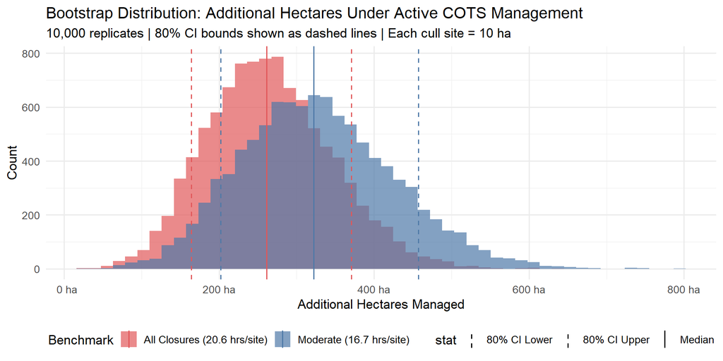

```r
hectare_data <- bind_rows(
  tibble::tibble(
    ha = moderate_sites * ha_per_site,
    benchmark = paste0("Moderate (", moderate_hrs, " hrs/site)")
  ),
  tibble::tibble(
    ha = all_sites * ha_per_site,
    benchmark = paste0("All Closures (", all_closure_hrs, " hrs/site)")
  )
)

ggplot(hectare_data, aes(x = ha, fill = benchmark)) +
  geom_histogram(bins = 50, alpha = 0.7, position = "identity") +
  geom_vline(data = hectare_data %>%
    group_by(benchmark) %>%
    summarise(
      med = median(ha),
      lo = quantile(ha, 0.10),
      hi = quantile(ha, 0.90),
      .groups = "drop"
    ) %>%
    tidyr::pivot_longer(cols = c(med, lo, hi), names_to = "stat", values_to = "val"),
    aes(xintercept = val, colour = benchmark, linetype = stat),
    linewidth = 0.7
  ) +
  scale_linetype_manual(values = c(med = "solid", lo = "dashed", hi = "dashed"),
                        labels = c("80% CI Lower", "80% CI Upper", "Median")) +
  scale_fill_manual(values = c(
    setNames("#4e79a7", paste0("Moderate (", moderate_hrs, " hrs/site)")),
    setNames("#e15759", paste0("All Closures (", all_closure_hrs, " hrs/site)"))
  )) +
  scale_colour_manual(values = c(
    setNames("#4e79a7", paste0("Moderate (", moderate_hrs, " hrs/site)")),
    setNames("#e15759", paste0("All Closures (", all_closure_hrs, " hrs/site)"))
  )) +
  scale_x_continuous(labels = function(x) paste0(format(x, big.mark = ","), " ha")) +
  labs(
    title = "Bootstrap Distribution: Additional Hectares Under Active COTS Management",
    subtitle = "10,000 replicates | 80% CI bounds shown as dashed lines | Each cull site = 10 ha",
    x = "Additional Hectares Managed",
    y = "Count",
    fill = "Benchmark", colour = "Benchmark"
  ) +
  theme_minimal(base_size = 13) +
  theme(legend.position = "bottom")
```

### Potential Scale: Manta-Only vs eDNA + Manta (No Scout Culling Required)

The comparison above requires an initial scout cull before a closure decision can be made. Below, we present the simpler rules that only require a Manta Tow (and optionally eDNA), with **no initial cull day needed**. Because no scout culling is involved, the full `Total_Diver_Hours` at the reef is the potential saving (no scout hours deducted).

```r
# ── Approach C: Manta Scars Only (Scars < 10%) ──────────────────
TN_count_scars <- sum(matrix_data_scars$Confusion_Class_Scars == "True Negative (Correctly Closed)")
TN_hrs_scars <- sum(matrix_data_scars$Total_Diver_Hours[matrix_data_scars$Confusion_Class_Scars == "True Negative (Correctly Closed)"], na.rm = TRUE)
FN_count_scars <- sum(matrix_data_scars$Confusion_Class_Scars == "False Negative (Missed Outbreak)")

Avg_Saved_Scars <- TN_hrs_scars / Total_Reefs_Ever_Tested
Avg_FN_Scars <- FN_count_scars / Total_Reefs_Ever_Tested

# ── Approach D: eDNA + Manta (eDNA < 45% AND Scars < 10%) ───────
TN_count_r1 <- sum(matrix_data_r1$Confusion_Class_R1 == "True Negative (Correctly Closed)")
TN_hrs_r1 <- sum(matrix_data_r1$Total_Diver_Hours[matrix_data_r1$Confusion_Class_R1 == "True Negative (Correctly Closed)"], na.rm = TRUE)
FN_count_r1 <- sum(matrix_data_r1$Confusion_Class_R1 == "False Negative (Missed Outbreak)")

Avg_Saved_R1 <- TN_hrs_r1 / Total_Reefs_Ever_Tested
Avg_FN_R1 <- FN_count_r1 / Total_Reefs_Ever_Tested

breakdown_manta_df <- tibble::tibble(
    Metric = c(
        "Total reef-years in validation dataset",
        "True Negatives (reefs correctly closed)",
        "Total post-eDNA diver hours saved (TN reefs, no scout deduction)",
        "False Negatives (missed outbreaks)",
        "Avg hours saved per reef-year (TN_hrs / total_reefs)",
        "Avg missed outbreaks per reef-year (FN_count / total_reefs)"
    ),
    `Approach C: Manta Only` = c(
        as.character(Total_Reefs_Ever_Tested),
        as.character(TN_count_scars),
        paste0(round(TN_hrs_scars, 1), " hrs"),
        as.character(FN_count_scars),
        paste0(round(Avg_Saved_Scars, 2), " hrs/reef"),
        round(Avg_FN_Scars, 3)
    ),
    `Approach D: eDNA + Manta` = c(
        as.character(Total_Reefs_Ever_Tested),
        as.character(TN_count_r1),
        paste0(round(TN_hrs_r1, 1), " hrs"),
        as.character(FN_count_r1),
        paste0(round(Avg_Saved_R1, 2), " hrs/reef"),
        round(Avg_FN_R1, 3)
    )
)
kable(breakdown_manta_df, caption = "Historical Per-Reef Averages: Manta-Only vs eDNA + Manta")
```

Historical Per-Reef Averages: Manta-Only vs eDNA + Manta

| Metric | Approach C: Manta Only | Approach D: eDNA + Manta |
| --- | --- | --- |
| Total reef-years in validation dataset | 73 | 73 |
| True Negatives (reefs correctly closed) | 22 | 14 |
| Total post-eDNA diver hours saved (TN reefs, no scout deduction) | 935.6 hrs | 724.7 hrs |
| False Negatives (missed outbreaks) | 13 | 3 |
| Avg hours saved per reef-year (TN_hrs / total_reefs) | 12.82 hrs/reef | 9.93 hrs/reef |
| Avg missed outbreaks per reef-year (FN_count / total_reefs) | 0.178 | 0.041 |

```r
# ── Scale to operational program ─────────────────────────────────
Operation_Saved_Scars <- Avg_Saved_Scars * operational_tactical_reefs
Operation_FN_Scars <- Avg_FN_Scars * operational_tactical_reefs
financial_savings_scars <- Operation_Saved_Scars * cost_per_diver_hour

Operation_Saved_R1 <- Avg_Saved_R1 * operational_tactical_reefs
Operation_FN_R1 <- Avg_FN_R1 * operational_tactical_reefs
financial_savings_r1 <- Operation_Saved_R1 * cost_per_diver_hour

# eDNA costs apply to Approach D only
net_savings_r1 <- financial_savings_r1 - cost_edna_testing

scaling_manta_df <- tibble::tibble(
    Metric = c(
        paste0("Avg hrs saved/reef × ", operational_tactical_reefs, " reefs"),
        "Projected annual hours saved",
        paste0("× $", format(cost_per_diver_hour, big.mark = ","), "/hr = Gross dollar savings"),
        paste0("Avg FN/reef × ", operational_tactical_reefs, " reefs"),
        "Projected missed outbreaks per year",
        "eDNA testing cost",
        "NET savings after eDNA costs"
    ),
    `Approach C: Manta Only` = c(
        paste0(round(Avg_Saved_Scars, 2), " × ", operational_tactical_reefs),
        paste0(format(round(Operation_Saved_Scars, 1), big.mark = ","), " hrs"),
        dollar(financial_savings_scars),
        paste0(round(Avg_FN_Scars, 3), " × ", operational_tactical_reefs),
        as.character(round(Operation_FN_Scars, 1)),
        "$0 (no eDNA needed)",
        dollar(financial_savings_scars)
    ),
    `Approach D: eDNA + Manta` = c(
        paste0(round(Avg_Saved_R1, 2), " × ", operational_tactical_reefs),
        paste0(format(round(Operation_Saved_R1, 1), big.mark = ","), " hrs"),
        dollar(financial_savings_r1),
        paste0(round(Avg_FN_R1, 3), " × ", operational_tactical_reefs),
        as.character(round(Operation_FN_R1, 1)),
        dollar(cost_edna_testing),
        dollar(net_savings_r1)
    )
)
kable(scaling_manta_df, caption = "Scaled to Operational Program: Manta-Only vs eDNA + Manta")
```

Scaled to Operational Program: Manta-Only vs eDNA + Manta

| Metric | Approach C: Manta Only | Approach D: eDNA + Manta |
| --- | --- | --- |
| Avg hrs saved/reef × 55 reefs | 12.82 × 55 | 9.93 × 55 |
| Projected annual hours saved | 704.9 hrs | 546 hrs |
| × $1,000/hr = Gross dollar savings | $704,929 | $546,007 |
| Avg FN/reef × 55 reefs | 0.178 × 55 | 0.041 × 55 |
| Projected missed outbreaks per year | 9.8 | 2.3 |
| eDNA testing cost | $0 (no eDNA needed) | $183,333 |
| NET savings after eDNA costs | $704,929 | $362,674 |

#### Summary (No Scout Culling)

**Approach C: Manta Scars Only** (Scars < 10%)

- **Operating Cost:** $0 extra.
- **Projected Annual Hours Saved:** 704.9 diver hours.
- **Gross Dollar Savings:** $704,929.
- **Operational Risk:** Expected to miss **9.8** genuine outbreaks per year.

**Approach D: eDNA + Manta** (eDNA < 45% + Scars < 10%)

- **Operating Cost:** $183,333 for eDNA testing.
- **Projected Annual Hours Saved:** 546 diver hours.
- **Gross Dollar Savings:** $546,007.
- **NET Savings (after eDNA costs):** $362,674.
- **Operational Risk:** Expected to miss **2.3** genuine outbreaks per year.

```r
# Extract required dynamic metrics for synthesis (Approach D: eDNA + Manta)
b_net_med <- boot_edna_manta$scaled %>% filter(metric == "Annual net savings (after eDNA costs)") %>% pull(median)
b_net_lo  <- boot_edna_manta$scaled %>% filter(metric == "Annual net savings (after eDNA costs)") %>% pull(ci_lower)
b_net_hi  <- boot_edna_manta$scaled %>% filter(metric == "Annual net savings (after eDNA costs)") %>% pull(ci_upper)

b_hrs_med <- boot_edna_manta$scaled %>% filter(metric == "Annual hours saved") %>% pull(median)
b_hrs_lo  <- boot_edna_manta$scaled %>% filter(metric == "Annual hours saved") %>% pull(ci_lower)
b_hrs_hi  <- boot_edna_manta$scaled %>% filter(metric == "Annual hours saved") %>% pull(ci_upper)

b_fn_med  <- boot_edna_manta$scaled %>% filter(metric == "Annual missed outbreaks (FN)") %>% pull(median)

# Days equivalent
days_med <- b_hrs_med / diver_hours_per_day
days_lo  <- b_hrs_lo / diver_hours_per_day
days_hi  <- b_hrs_hi / diver_hours_per_day

cat(paste0(
  "## Executive Synthesis: Major Findings & Analytical Assumptions\n\n",
  "This section consolidates the overarching findings of the ROI analysis at a projected operational scale of **", operational_tactical_reefs, " tactical reefs per year**, followed by an exhaustive inventory of all technical, financial, and ecological assumptions governing the analytical pipeline.\n\n",

  "### 1. Summary of Major Findings\n\n",

  "::: {.callout-important}\n",
  "## Key Strategic Takeaways\n\n",

  "1. **Substantial Net Return on Investment (Approach D - eDNA + Manta):**\n",
  "   - **Net Financial Savings:** Generating **", dollar(b_net_med), " per year** in net savings (80% CI: ", dollar(b_net_lo), " – ", dollar(b_net_hi), ") **after fully deducting** the ", dollar(program_cost), " annual eDNA program budget.\n",
  "   - **High Financial Reliability:** ", round(boot_edna_manta$breakeven_prob * 100, 1), "% of bootstrap resamples produce positive net savings, demonstrating strong financial resilience against sampling variability.\n\n",

  "2. **Diver Effort Avoided (Eliminating Ghost Culls):**\n",
  "   - **Avoided Diver Time:** **", format(round(b_hrs_med, 0), big.mark = ","), " diver hours saved per year** (80% CI: ", format(round(b_hrs_lo, 0), big.mark = ","), " – ", format(round(b_hrs_hi, 0), big.mark = ","), ") by preventing vessel deployment on non-outbreak reefs.\n",
  "   - **Equivalent Vessel Capacity:** Represents redirecting **~", round(days_med, 1), " full on-water operational vessel days** per year (80% CI: ", round(days_lo, 1), " – ", round(days_hi, 1), " days) back into active outbreak management.\n\n",

  "3. **Ecological Impact: Expanding Managed Reef Footprint:**\n",
  "   - **Additional Hectares Managed (Closed Outbreaks):** Redirecting saved hours allows closing **+", round(mod_q[2], 0), " additional moderate-density cull sites** (80% CI: ", round(mod_q[1], 0), " – ", round(mod_q[3], 0), "), protecting **+", format(round(mod_q[2] * ha_per_site, 0), big.mark = ","), " additional hectares** of coral reef area per year.\n",
  "   - **Growth in Closed Area:** Represents a **", round(pct_inc_ha_mod_q[2], 1), "% increase** (80% CI: ", round(pct_inc_ha_mod_q[1], 1), "% – ", round(pct_inc_ha_mod_q[3], 1), "%) over the historical baseline of ", round(avg_closures_per_year, 1), " closed sites/year (290 ha/year).\n",
  "   - **Expansion in Actioned Sites:** Using the median effort per actioned site (", median_actioned_hrs, " hrs/site), saved hours enable visiting **+", round(actioned_q[2], 0), " additional distinct sites** per year (80% CI: ", round(actioned_q[1], 0), " – ", round(actioned_q[3], 0), "), a **", round(pct_inc_actioned_q[2], 1), "% increase** over the historical baseline of ", format(round(avg_actioned_per_year, 0), big.mark = ","), " actioned sites/year.\n\n",

  "4. **Ecological Safety & Risk Control:**\n",
  "   - **Negligible Missed Outbreaks:** Approach D restricts missed outbreaks to an expected **", round(b_fn_med, 2), " reefs per year**, providing near-perfect ecological safety while eliminating wasted effort.\n",
  ":::\n\n",

  "---\n\n",

  "### 2. Comprehensive Inventory of Analytical Assumptions\n\n",
  "To ensure complete transparency and reproducibility, the entire evaluation pipeline relies on the following explicit assumptions across five operational domains:\n\n",

  "#### A. Data Preparation & Temporal Matching Assumptions\n",
  "* **Matching Unit:** Data are matched at the discrete **reef-year** level. eDNA sample results collected on a reef in a given year are paired with Manta Tow surveys and active culling logs for that exact same reef-year.\n",
  "* **Post-eDNA Temporal Filtering (Causality Constraint):** To prevent post-hoc bias, **only culling effort that occurred on or after the earliest eDNA sampling date** in a given reef-year is evaluated for potential savings. Effort occurring *before* eDNA sampling cannot physically be avoided by eDNA-informed decisions and is strictly excluded from savings metrics.\n",
  "* **Exclusion of Pre-eDNA-Only Reef-Years:** Reef-years where all culling occurred prior to eDNA sampling are excluded from confusion matrix scoring as no post-eDNA decisions could be evaluated.\n",
  "* **Multi-Year Data Scope:** Analysis incorporates historical records from **2020 through 2025** (n = ", nrow(full_matched_data), " matched reef-year validation events). The year 2026 is excluded due to incomplete annual culling logs.\n\n",

  "#### B. Outbreak Definition & Ground Truth ('Ghost Cull') Assumptions\n",
  "* **Active Outbreak Ground Truth Threshold:** A reef-year is defined as a **True Outbreak (Needed)** if *any dive* on that reef during the post-eDNA period registered a Catch Per Unit Effort (CPUE) $\\ge 0.04$ COTS/diver-minute (Cohort 1–4 total COTS / bottom time).\n",
  "* **Ghost Cull Definition (False Positive):** A reef is classified as a 'Ghost Cull' if a decision rule recommended keeping it open for culling, but subsequent dive logs prove **zero dives ever exceeded 0.04 CPUE**.\n",
  "* **Missed Outbreak Definition (False Negative):** A reef is classified as a 'Missed Outbreak' if a decision rule recommended closing the reef, but subsequent dive logs confirmed at least one dive $\\ge 0.04$ CPUE. Models heavily penalize false negatives.\n\n",

  "#### C. Operational Scale & Financial Assumptions\n",
  "* **Operational Scale Target:** Results are scaled to a projected operational deployment across **", operational_tactical_reefs, " tactical reefs per year**.\n",
  "* **Diver Hour Financial Valuation:** Diver effort is valued at **$", format(cost_per_diver_hour, big.mark = ","), " per diver hour**, calculated directly from vessel daily operating costs ($", format(cost_per_on_water_day, big.mark = ","), " per on-water day / ", diver_hours_per_day, " diver hours per day).\n",
  "* **eDNA Program Fixed Cost:** Total eDNA program cost is set at **$", format(program_cost, big.mark = ","), " per year** across 120 surveyed reefs, establishing an average cost of **$", format(round(edna_cost_per_reef, 2), big.mark = ","), " per reef**.\n",
  "* **Scout Cull Hour Deduction:** For decision rules requiring an initial in-water scout check (Approaches A and B), Day-1 scout dive hours (`Scout_Diver_Hours`) are strictly deducted from True Negative savings yields. For Approach D (eDNA + Manta), no in-water scout culling is required prior to closure, allowing 100% of post-eDNA diver hours on non-outbreak reefs to be saved.\n\n",

  "#### D. Ecological Conversion & Baseline Assumptions\n",
  "* **Cull Site Polygon Area:** Standardized at **10 hectares (ha)** per cull site.\n",
  "* **Moderate Outbreak Closure Effort Benchmark:** Set at **", moderate_hrs, " diver hours per site**, representing the empirical median effort required to suppress moderate outbreaks (0.04–0.08 peak CPUE) to below 0.04 CPUE.\n",
  "* **All-Closures Effort Benchmark:** Set at **", all_closure_hrs, " diver hours per site**, representing the overall median closure effort across all density classes.\n",
  "* **Actioned Site Effort Benchmark:** Set at **", median_actioned_hrs, " diver hours per site-year**, representing the empirical median annual effort spent across all actioned sites (both closed and ongoing).\n",
  "* **Historical Closure Baseline:** Historical average of **", round(avg_closures_per_year, 1), " closed sites per year** (", format(round(avg_closures_per_year * ha_per_site, 0), big.mark = ","), " ha/year) across 2020–2025.\n",
  "* **Historical Actioned Baseline:** Historical average of **", format(round(avg_actioned_per_year, 0), big.mark = ","), " actioned sites per year** across 2020–2025.\n\n",

  "#### E. Uncertainty & Statistical Resampling Assumptions\n",
  "* **Bootstrap Resampling Framework:** Non-parametric case-resampling bootstrap with **10,000 iterations** at the reef-year observation level.\n",
  "* **Confidence Intervals:** 80% non-parametric percentile confidence intervals (10th to 90th percentiles) chosen to reflect operational risk planning thresholds.\n\n"
))
```

## Executive Synthesis: Major Findings & Analytical Assumptions

This section consolidates the overarching findings of the ROI analysis at a projected operational scale of **55 tactical reefs per year**, followed by an exhaustive inventory of all technical, financial, and ecological assumptions governing the analytical pipeline.

### 2. Comprehensive Inventory of Analytical Assumptions

#### A. Data Preparation & Temporal Matching Assumptions

- **Matching Unit:** Data are matched at the discrete **reef-year** level. eDNA sample results collected on a reef in a given year are paired with Manta Tow surveys and active culling logs for that exact same reef-year.
- **Post-eDNA Temporal Filtering (Causality Constraint):** To prevent post-hoc bias, **only culling effort that occurred on or after the earliest eDNA sampling date** in a given reef-year is evaluated for potential savings. Effort occurring *before* eDNA sampling cannot physically be avoided by eDNA-informed decisions and is strictly excluded from savings metrics.
- **Exclusion of Pre-eDNA-Only Reef-Years:** Reef-years where all culling occurred prior to eDNA sampling are excluded from confusion matrix scoring as no post-eDNA decisions could be evaluated.
- **Multi-Year Data Scope:** Analysis incorporates historical records from **2020 through 2025** (n = 73 matched reef-year validation events). The year 2026 is excluded due to incomplete annual culling logs.

#### B. Outbreak Definition & Ground Truth (‘Ghost Cull’) Assumptions

- **Active Outbreak Ground Truth Threshold:** A reef-year is defined as a **True Outbreak (Needed)** if *any dive* on that reef during the post-eDNA period registered a Catch Per Unit Effort (CPUE) $\ge 0.04$ COTS/diver-minute (Cohort 1–4 total COTS / bottom time).
- **Ghost Cull Definition (False Positive):** A reef is classified as a ‘Ghost Cull’ if a decision rule recommended keeping it open for culling, but subsequent dive logs prove **zero dives ever exceeded 0.04 CPUE**.
- **Missed Outbreak Definition (False Negative):** A reef is classified as a ‘Missed Outbreak’ if a decision rule recommended closing the reef, but subsequent dive logs confirmed at least one dive $\ge 0.04$ CPUE. Models heavily penalize false negatives.

#### D. Ecological Conversion & Baseline Assumptions

- **Cull Site Polygon Area:** Standardized at **10 hectares (ha)** per cull site.
- **Moderate Outbreak Closure Effort Benchmark:** Set at **16.7 diver hours per site**, representing the empirical median effort required to suppress moderate outbreaks (0.04–0.08 peak CPUE) to below 0.04 CPUE.
- **All-Closures Effort Benchmark:** Set at **20.6 diver hours per site**, representing the overall median closure effort across all density classes.
- **Actioned Site Effort Benchmark:** Set at **9.2 diver hours per site-year**, representing the empirical median annual effort spent across all actioned sites (both closed and ongoing).
- **Historical Closure Baseline:** Historical average of **194.5 closed sites per year** (1,945 ha/year) across 2020–2025.
- **Historical Actioned Baseline:** Historical average of **1,144 actioned sites per year** across 2020–2025.

#### E. Uncertainty & Statistical Resampling Assumptions

- **Bootstrap Resampling Framework:** Non-parametric case-resampling bootstrap with **10,000 iterations** at the reef-year observation level.
- **Confidence Intervals:** 80% non-parametric percentile confidence intervals (10th to 90th percentiles) chosen to reflect operational risk planning thresholds.

## Deep Dive: Most Recent Example Year

The table below provides transparency out of the most recent example year to show you the hour breakdown by precise density bins alongside their associated metrics enabling multivariate closures.

```r
# We keep 2025 as the example deep dive
most_recent_year <- max(combined_data$Year - 1, na.rm = TRUE)

# recent_top_20 <- top_20_annual %>%
recent_top_20 <- combined_data %>%
    filter(Year == most_recent_year) %>%
    select(
        ReefName,
        Total_Diver_Hours,
        Wasted_Diver_Hours,
        Proportion_Wasted,
        Proportion_Borderline,
        Proportion_NeededLow,
        Proportion_NeededHigh,
        eDNA_Pct_Positive,
        eDNA_Mean_Conc
    ) %>%
    mutate(
        Total_Diver_Hours = round(Total_Diver_Hours, 1),
        Wasted_Diver_Hours = round(Wasted_Diver_Hours, 1),
        Proportion_Wasted = paste0(round(Proportion_Wasted * 100, 1), "%"),
        Proportion_Borderline = paste0(round(Proportion_Borderline * 100, 1), "%"),
        Proportion_NeededLow = paste0(round(Proportion_NeededLow * 100, 1), "%"),
        Proportion_NeededHigh = paste0(round(Proportion_NeededHigh * 100, 1), "%"),
        eDNA_Pct_Positive = paste0(round(eDNA_Pct_Positive, 1), "%"),
        eDNA_Pct_Positive = ifelse(eDNA_Pct_Positive == "NA%", "No Data", eDNA_Pct_Positive),
        eDNA_Mean_Conc = round(eDNA_Mean_Conc, 3)
    ) %>%
    # arrange(desc(Wasted_Diver_Hours))
    arrange(eDNA_Pct_Positive)

kable(
    recent_top_20,
    col.names = c("Reef Name", "Tot Dive Hrs", "Wasted Dive Hrs", "% 0-0.02", "% 0.02-0.04", "% 0.04-0.08", "% >0.08", "eDNA % Pos", "eDNA Mean Conc"),
    caption = paste("Worst-Performing Tactical Reefs in", most_recent_year, "(Deep Dive Example)")
)
```

| Reef Name | Tot Dive Hrs | Wasted Dive Hrs | % 0-0.02 | % 0.02-0.04 | % 0.04-0.08 | % >0.08 | eDNA % Pos | eDNA Mean Conc |
| --- | --- | --- | --- | --- | --- | --- | --- | --- |
| Lizard Island Reef (North West) (14-116a) | 71.7 | 38.3 | 53.5% | 46.5% | 0% | 0% | 15% | 1.725 |
| U/N Reef (21-057) | 28.5 | 19.0 | 66.7% | 33.3% | 0% | 0% | 16.7% | 1.568 |
| Green Island Reef (16-049) | 56.7 | 20.0 | 35.3% | 44.1% | 10.3% | 10.3% | 22.2% | 3.201 |
| Tongue Reef (16-026) | 29.8 | 0.0 | 0% | 0% | 32.8% | 67.2% | 38.9% | 4.741 |
| U/N Reef (21-069) | 11.8 | 11.8 | 100% | 0% | 0% | 0% | 4.2% | 0.348 |
| Lizard Island Reef (North East) (14-116b) | 11.2 | 11.2 | 100% | 0% | 0% | 0% | 45% | 7.674 |
| (Big) Broadhurst Reef (No 1) (18-100a) | 496.2 | 261.0 | 52.6% | 17.5% | 14.1% | 15.8% | 50% | 7.625 |
| U/N Reef (21-067) | 14.3 | 0.0 | 0% | 0% | 25.2% | 74.8% | 50% | 18.442 |
| U/N Reef (20-386) | 69.4 | 18.0 | 25.9% | 18.5% | 20.9% | 34.7% | 52.1% | 14.812 |
| U/N Reef (21-094) | 51.5 | 51.5 | 100% | 0% | 0% | 0% | 66.7% | 11.727 |
| Batt Reef (16-029) | 830.2 | 58.9 | 7.1% | 9.9% | 23.4% | 59.6% | 76.2% | 16.128 |
| Bowden Reef (19-019) | 147.6 | 101.1 | 68.5% | 8% | 20.8% | 2.7% | 76.2% | 16.151 |
| Lizard Island Reef (Lagoon) (14-116d) | 67.7 | 19.0 | 28.1% | 28% | 35.7% | 8.3% | 76.7% | 26.881 |
| Judith Wright Reef (18-101) | 144.4 | 56.6 | 39.2% | 19% | 25.2% | 16.6% | 79.2% | 131.478 |
| U/N Reef (21-092) | 9.0 | 9.0 | 100% | 0% | 0% | 0% | 79.2% | 41.938 |
| U/N Reef (21-460) | 59.9 | 59.9 | 100% | 0% | 0% | 0% | 8.3% | 1.000 |
| U/N Reef (21-466) | 120.2 | 120.2 | 100% | 0% | 0% | 0% | 8.3% | 0.938 |
| U/N Reef (21-250a) | 33.3 | 16.4 | 49.4% | 36.6% | 14% | 0% | 83.3% | 15.536 |
| Bushy-Redbill Reef (20-310) | 35.4 | 0.0 | 0% | 0% | 0% | 100% | 87.5% | 54.667 |
| Banfield Reef (North) (18-105a) | 531.6 | 37.7 | 7.1% | 15% | 29.6% | 48.3% | 91.7% | 66.485 |
| Davies Reef (18-096) | 177.7 | 102.0 | 57.4% | 27.4% | 15.2% | 0% | 95.2% | 71.802 |
| (Little) Broadhurst Reef (18-106) | 172.3 | 71.7 | 41.6% | 29.7% | 21.4% | 7.4% | No Data | NA |
| Adelaide Reef (17-042) | 13.3 | 13.3 | 100% | 0% | 0% | 0% | No Data | NA |
| Arlington Reef (16-064) | 48.5 | 32.4 | 66.8% | 23.9% | 9.3% | 0% | No Data | NA |
| Backnumbers Reef (18-069a) | 77.7 | 35.0 | 45.1% | 54.9% | 0% | 0% | No Data | NA |
| Banfield Reef (South) (18-105b) | 35.2 | 3.5 | 9.9% | 41.5% | 26.8% | 21.8% | No Data | NA |
| Barnett Patches (18-019) | 149.2 | 142.8 | 95.8% | 4.2% | 0% | 0% | No Data | NA |
| Black Island Reef (20-017) | 34.9 | 34.9 | 100% | 0% | 0% | 0% | No Data | NA |
| Block Reef (19-127) | 13.4 | 9.7 | 72.6% | 27.4% | 0% | 0% | No Data | NA |
| Boult Reef (23-079) | 159.5 | 70.3 | 44.1% | 16.6% | 11.6% | 27.7% | No Data | NA |

[output cut: 112 more lines]

### Spatial Output: Risk Classification Map

To fully visualize how these operational recommendations fall out across the GBR, this interactive map projects every historical validation event natively against the field landscape. Because each Reef may be tested in multiple different years, you can natively toggle the analytical projection overlay by **Year** using the layers control widget on the right.

You can cross-reference our operational “Approach A” (Field Data Only logic) directly against “Approach B” (Integrated eDNA framework) classifications natively over the raw historical sampling footprints.

```r
# 1. Base Geometry Linkage =======================================
edna_raw <- readxl::read_excel("../data/eDNA data_ALL_20260225.xlsx", sheet = "eDNA_data_ALL")
cull_raw <- readxl::read_excel("../data/260201_COTS-Cull-Data-Ewels.xlsx", sheet = "Cull")
manta_raw <- read.csv("../data/COTS Program  Manta Tow Data-2026-02-04.csv", stringsAsFactors = FALSE)

# Generate average lat/long per reef from edna raw data
reef_coords <- edna_raw %>%
    filter(!is.na(Lat) & !is.na(Long)) %>%
    group_by(ReefName = ReefName) %>%
    summarise(
        Lat = mean(as.numeric(Lat), na.rm = TRUE),
        Long = mean(as.numeric(Long), na.rm = TRUE),
        .groups = "drop"
    )

# Bind geometry to our modeled matrices
map_data_r2 <- matrix_data_r2 %>% left_join(reef_coords, by = "ReefName")
map_data_field <- matrix_data_field %>% left_join(reef_coords, by = "ReefName")

# 2. Build Tooltips ============================================
conf_colors <- c(
    "True Negative (Correctly Closed)" = "green",
    "False Negative (Missed Outbreak)" = "red",
    "True Positive (Correctly Kept Open)" = "blue",
    "False Positive (Ghost Culled)" = "gray"
)


# 3. Formulate Background Geo-Layers ============================
# KML Cull Polygons
cull_gpkg <- "../data/Eotr_CotsCullSites_2025_11_19_1_58_PM.gpkg"
if (file.exists(cull_gpkg)) {
    cull_sites_sf <- sf::st_read(cull_gpkg, quiet = TRUE)
} else {
    tmp_kml_dir <- tempfile("kmz_")
    dir.create(tmp_kml_dir)
    unzip("../data/Eotr_CotsCullSites_2025_11_19_1_58_PM.kmz", exdir = tmp_kml_dir)
    kml_layers <- sf::st_layers(file.path(tmp_kml_dir, "doc.kml"))$name
    cull_sites_sf <- do.call(rbind, lapply(kml_layers, function(l) {
        sf::st_read(file.path(tmp_kml_dir, "doc.kml"), layer = l, quiet = TRUE)
    })) |> sf::st_zm(drop = TRUE)
    sf::st_write(cull_sites_sf, dsn = cull_gpkg, driver = "GPKG", append = FALSE, quiet = TRUE)
}

unique_years <- sort(unique(map_data_r2$Year))
max_test_year <- max(unique_years, na.rm = TRUE)

cpue_levels <- c("< 0.01 CPUE", "0.01-0.04 CPUE", "0.04-0.08 CPUE", "> 0.08 CPUE")
cpue_colours <- c("#3288BD", "#FEE08B", "#FC8D59", "#D53E4F")
pal_cpue <- colorFactor(palette = cpue_colours, levels = cpue_levels, ordered = TRUE)

# Cull Sites mapped to latest CPUE Categories
cull_site_latest <- cull_raw |>
    filter(!is.na(CullSiteName)) |>
    filter(SurveyDate >= as.Date(paste0(max_test_year, "-01-01"))) |>
    group_by(CullSiteName) |>
    arrange(desc(SurveyDate)) |>
    slice(1) |>
    ungroup() |>
    mutate(
        site_cots = as.numeric(Cohort1) + as.numeric(Cohort2) + as.numeric(Cohort3) + as.numeric(Cohort4),
        site_cots = ifelse(is.na(site_cots), 0, site_cots),
        site_cpue = round(site_cots / as.numeric(Bottomtime), 4),
        cpue_category = case_when(
            site_cpue >= 0.08 ~ "> 0.08 CPUE",
            site_cpue >= 0.04 ~ "0.04-0.08 CPUE",
            site_cpue >= 0.01 ~ "0.01-0.04 CPUE",
            TRUE ~ "< 0.01 CPUE"
        ),
        cpue_category = factor(cpue_category, levels = cpue_levels)
    )

cull_sites_map <- cull_sites_sf |>
    left_join(cull_site_latest, by = c("Name" = "CullSiteName")) |>
    filter(!is.na(site_cpue))

cull_site_popups <- paste0(
    "<b>Cull Site: ", cull_sites_map$Name, "</b><br>",
    "Latest CPUE: ", cull_sites_map$site_cpue, " COTS/min<br>",
    "<b>Category: ", as.character(cull_sites_map$cpue_category), "</b>"
)

# Manta Tracks (Recent/All)
manta_tracks <- manta_raw |>
    mutate(
        SurveyDate = as.Date(substr(SurveyTime, 1, 10)),
        ScarsCount = case_when(
            !is.na(as.numeric(ScarsCount)) ~ as.numeric(ScarsCount),
            tolower(FeedingScarCountRangeCode) == "a" ~ 0,
            tolower(FeedingScarCountRangeCode) == "p" ~ 4,
            tolower(FeedingScarCountRangeCode) == "c" ~ 10,
            TRUE ~ 0
        )
    ) |>
    filter(SurveyDate >= as.Date(paste0(max_test_year, "-01-01"))) |> # Render only the most recent year's tracks to keep mapping lightweight!
    filter(!is.na(StartLatitude), !is.na(EndLatitude), !is.na(StartLongitude), !is.na(EndLongitude)) |>
    rowwise() |>
    mutate(
        geometry = sf::st_sfc(sf::st_linestring(matrix(c(as.numeric(StartLongitude), as.numeric(EndLongitude), as.numeric(StartLatitude), as.numeric(EndLatitude)), ncol = 2)))
    ) |>
    ungroup() |>
    sf::st_as_sf(crs = 4326)

pal_manta_scars <- colorNumeric(palette = "RdYlBu", domain = 0:10, reverse = TRUE)

manta_cots_pts <- manta_tracks |> filter(as.numeric(CrownOfThornsStarfishCount) > 0)
if (nrow(manta_cots_pts) > 0) manta_cots_pts <- sf::st_centroid(manta_cots_pts)

# Dynamic eDNA internal threshold compute matching the actual analysis limits

cb_calc <- combined_data %>%
    filter(!is.na(eDNA_Pct_Positive), !is.na(eDNA_Mean_Conc), !is.na(Initial_CPUE)) %>%
    mutate(
        conc_t = log1p(eDNA_Mean_Conc),
        cpue = Initial_CPUE,
        perc_pos = eDNA_Pct_Positive
    )

perc_grid <- seq(0, 100, by = 5)
conc_grid_t <- seq(min(cb_calc$conc_t, na.rm = TRUE), quantile(cb_calc$conc_t, 0.99, na.rm = TRUE), length.out = 30)

thr_01 <- best_pair(cb_calc, 0.01, perc_grid, conc_grid_t)
thr_04 <- best_pair(cb_calc, 0.04, perc_grid, conc_grid_t)
thr_08 <- best_pair(cb_calc, 0.08, perc_grid, conc_grid_t)

# Raw eDNA sites
edna_sites <- edna_raw %>%
    mutate(date_edna = as.Date(Date)) %>%
    filter(date_edna >= as.Date(paste0(max_test_year, "-01-01"))) |>
    filter(!is.na(Lat) & !is.na(Long)) |>
    mutate(Lat = as.numeric(Lat), Long = as.numeric(Long)) |>
    group_by(Reef = ReefName, Lat, Long) %>%
    summarise(
        date_edna = min(date_edna, na.rm = T),
        conc_mean = mean(as.numeric(Conc_mean), na.rm = T),
        perc_pos = mean(LOD_sample_positive, na.rm = T) * 100,
        n = n(),
        .groups = "drop"
    ) %>%
    mutate(
        conc_t = log1p(conc_mean),
        cpue_category = case_when(
            perc_pos >= thr_08$perc_star & conc_t >= thr_08$conc_t_star ~ "> 0.08 CPUE",
            perc_pos >= thr_04$perc_star & conc_t >= thr_04$conc_t_star ~ "0.04-0.08 CPUE",
            perc_pos >= thr_01$perc_star & conc_t >= thr_01$conc_t_star ~ "0.01-0.04 CPUE",
            TRUE ~ "< 0.01 CPUE"
        ),
        cpue_category = factor(cpue_category, levels = cpue_levels),
        marker_col = case_when(
            as.integer(cpue_category) == 1L ~ "blue",
            as.integer(cpue_category) == 2L ~ "orange",
            as.integer(cpue_category) == 3L ~ "red",
            as.integer(cpue_category) == 4L ~ "darkred",
            TRUE ~ "gray"
        )
    )

edna_site_popups <- paste0(
    "<b>eDNA Site (", edna_sites$Reef, ")</b><br>",
    "Survey Date: ", format(edna_sites$date_edna, "%d %b %Y"), "<br>",
    "<b>% Positive: ", round(edna_sites$perc_pos, 1), "%</b><br>",
    "<b>Mean Conc: ", round(edna_sites$conc_mean, 2), " copies/rxn</b><br>",
    "Samples: ", edna_sites$n, "<br>",
    "<b>Expected CPUE: ", as.character(edna_sites$cpue_category), "</b>"
)

site_icons <- awesomeIcons(icon = "flask", iconColor = "white", library = "fa", markerColor = edna_sites$marker_col)

# 4. Generate Interactive Map Base =============================
map <- leaflet(width = "100%", height = "700px") |>
    addProviderTiles(providers$Esri.WorldImagery, options = providerTileOptions(maxZoom = 18)) |>
    setView(lng = 147, lat = -18, zoom = 6)

overlay_groups_list <- c()

# Add Background Asset Layers
map <- map |>
    addPolygons(
        data = cull_sites_map,
        color = "#ffffff", weight = 1.0,
        fillColor = ~ pal_cpue(cpue_category),
        fillOpacity = 0.5,
        popup = cull_site_popups,
        group = "Background: KML Cull Polygons"
    ) |>
    addAwesomeMarkers(
        data = edna_sites, lng = ~Long, lat = ~Lat, icon = site_icons, popup = edna_site_popups,
        group = "Background: eDNA Drop Points"
    ) |>
    addPolylines(
        data = manta_tracks, color = ~ pal_manta_scars(ScarsCount), weight = 3, opacity = 0.8,
        popup = ~ paste0("Reef: ", ReefLabel, "<br>COTS: ", CrownOfThornsStarfishCount, "<br>Scars: ", ScarsCount),
        group = "Background: Manta Tows"
    ) |>
    addCircleMarkers(
        data = manta_cots_pts, radius = 4, color = "black", weight = 1, fillColor = "red", fillOpacity = 1,
        popup = ~ paste0("<b>COTS Detected!</b><br>Count: ", CrownOfThornsStarfishCount),
        group = "Background: Manta Tows (COTS > 0)"
    )

overlay_groups_list <- c("Background: KML Cull Polygons", "Background: eDNA Drop Points", "Background: Manta Tows", "Background: Manta Tows (COTS > 0)")

# 5. Inject Predictive Layers Loop (by Year) ====================
unique_years <- sort(unique(map_data_r2$Year))

for (yr in unique_years) {
    yr_data_r2 <- map_data_r2 %>%
        filter(Year == yr) %>%
        filter(!is.na(Lat))
    yr_data_fd <- map_data_field %>%
        filter(Year == yr) %>%
        filter(!is.na(Lat))

    layer_name_r2 <- paste0(yr, " - Approach B: Integrated eDNA")
    layer_name_fd <- paste0(yr, " - Approach A: Field Data Only")

    # Inject Rule 2 Layer
    if (nrow(yr_data_r2) > 0) {
        map <- map %>% addCircleMarkers(
            data = yr_data_r2,
            lng = ~Long, lat = ~Lat,
            radius = 11, weight = 2, color = "white", fillOpacity = 0.9,
            fillColor = ~ unname(conf_colors[Confusion_Class_R2]),
            popup = ~ build_popup(ReefName, Year, eDNA_Pct_Positive, Pct_Tows_With_Scars, Initial_CPUE, Truth_Needed, Confusion_Class_R2, "Approach B: Integrated (eDNA < 50, Scars < 15, CPUE < 0.02)"),
            group = layer_name_r2
        )
    }

    # Inject Field Only Layer
    if (nrow(yr_data_fd) > 0) {
        map <- map %>% addCircleMarkers(
            data = yr_data_fd,
            lng = ~Long, lat = ~Lat,
            radius = 8, weight = 2, color = "black", fillOpacity = 0.9,
            fillColor = ~ unname(conf_colors[Confusion_Class_Field]),
            popup = ~ build_popup(ReefName, Year, eDNA_Pct_Positive, Pct_Tows_With_Scars, Initial_CPUE, Truth_Needed, Confusion_Class_Field, "Approach A: Field Only (Scars < 15, CPUE < 0.02)"),
            group = layer_name_fd
        )
    }

    overlay_groups_list <- c(overlay_groups_list, layer_name_r2, layer_name_fd)
}

# 6. Final Control & Assembly ===================================
map <- map |>
    addLegend(
        position = "bottomright",
        colors = unname(conf_colors),
        labels = names(conf_colors),
        title = "Validation Outcome",
        opacity = 1
    ) %>%
    addLayersControl(
        overlayGroups = overlay_groups_list,
        options = layersControlOptions(collapsed = FALSE)
    ) %>%
    hideGroup(overlay_groups_list) %>%
    showGroup(c("Background: KML Cull Polygons", paste0(max(unique_years), " - Approach B: Integrated eDNA")))

map
```

[interactive chart not shown]